# Reproducible Research: Peer Assessment 1

## Loading and preprocessing the data

The initial preparation of the activity data:

```r
setwd("~/Projects/RepData_PeerAssessment1")
activity <- read.csv("activity.csv")
activity$date <- as.Date(activity$date, format = "%Y-%m-%d")
```

## What is mean total number of steps taken per day?

Let's get a sense of the distribution of steps per day by building a histogram:

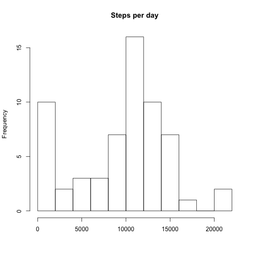

```r
library(reshape2)
steps_per_day <- dcast(activity, date ~ ., fun.aggregate = sum, na.rm = TRUE, value.var = "steps")
hist(steps_per_day$., breaks = 10, xlab = "", main = "Steps per day")
```

The mean and median steps per day:

```r
mean_steps <- round(mean(steps_per_day$.), 0)
median_steps <- median(steps_per_day$.)
paste("Mean: ", mean_steps, ", Median: ", median_steps, sep="")
```

```
## [1] "Mean: 9354, Median: 10395"
```

## What is the average daily activity pattern?

Let's look at the 5-minute intervals averaged across all the days:

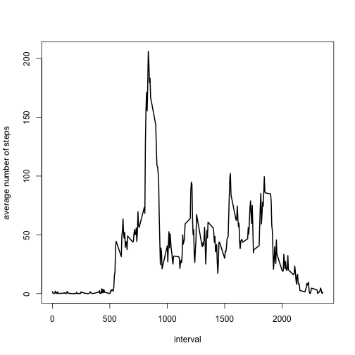

```r
intervals <- dcast(activity, interval ~ ., fun.aggregate = mean, na.rm = TRUE, value.var = "steps")
with(intervals, plot(interval, ., type = "l", lwd = 2, ylab = "average number of steps"))
```

We can see a peak in the average steps for a given interval somewhere between 700 and 1000. To find the interval with the maximum number of steps:

```r
intervals$interval[which.max(intervals$.)]
```

```
## [1] 835
```

## Imputing missing values

Let's find out how many missing values there are in the dataset:

```r
sum(is.na(activity$steps))
```

```
## [1] 2304
```

This corresponds to a percentage of the total step measurements:

```r
round(100 * sum(is.na(activity$steps))/length(activity$steps))
```

```
## [1] 13
```

One way to deal with these missing values is to substitute in the mean value for that interval. Let's duplicate `activity` into a data frame `activity_filled`:

```r
activity_filled <- activity
for (i in 1:nrow(activity_filled)) {
  if(is.na(activity_filled[i,"steps"])) {
    interval <- activity_filled[i,"interval"]
    fill_value <- intervals[intervals$interval == interval, "."]
    activity_filled[i,"steps"] <- fill_value
  }
}
```

With the missing values filled in, let's look at a histogram:

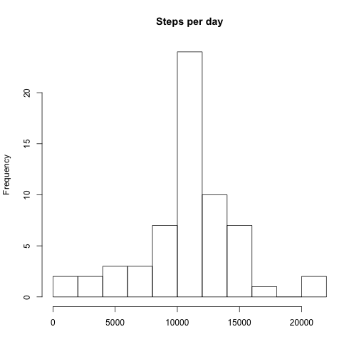

```r
steps_per_day_filled <- dcast(activity_filled, date ~ ., fun.aggregate = sum, na.rm = TRUE, value.var = "steps")
hist(steps_per_day_filled$., breaks = 10, xlab = "", main = "Steps per day")
```

The mean and median steps per day:

```r
mean_steps_filled <- round(mean(steps_per_day_filled$.), 0)
median_steps_filled <- round(median(steps_per_day_filled$.))
paste("Mean: ", mean_steps, ", Median: ", median_steps, sep="")
```

```
## [1] "Mean: 9354, Median: 10395"
```

## Are there differences in activity patterns between weekdays and weekends?

Identifying dates as “weekday” or “weekend” can be extracted out into a function:

```r
weekend <- function(dates) {
  dayofweek <- weekdays(dates)
  ifelse(dayofweek == "Saturday" | dayofweek == "Sunday", "weekend", "weekday")
}
```

Then we can add a variable to our `activity_filled` data frame and compute the average steps over interval and weekend values:

```r
activity_filled$weekend <- factor(weekend(activity_filled$date))
interval_weekend <- dcast(activity_filled, interval + weekend  ~ ., fun.aggregate = mean, na.rm = TRUE, value.var = "steps")
```

To create the plot, we can use ggplot with the facet_grid:

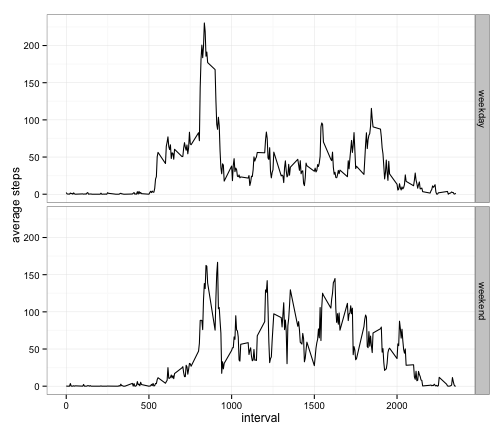

```r
library(ggplot2)
g <- ggplot(interval_weekend, aes(interval, .))
g + geom_line() + facet_grid(weekend ~ .) + theme_bw() + ylab("average steps")
```